# Lab 7: One-Way Anova

Caijun Qin

### Tire’s Lifetime

Suppose that as a business manager you have the responsibility for testing and comparing the lifetimes of four brands (Apollo, Bridgestone, CEAT and Falken) of automobile tires. The lifetime of these sample observations are measured in mileage run in thousands. For each brand of automobile tire, a sample of 15 observations have been collected. Using this information, you have to recommend the brand or brands with the best performance (if any). The data is provided in the `tire.csv` file.

To read the data, download it to the same folder where you have your .Rmd file for this lab. Then set your working directory using the `setwd` command and providing the folder path in your computer, or choosing `Set Working Directory` in the `Session` tab in Rstudio:

```r
# read data
tire <- read.csv("tire.csv", header=T)
```

**Exercise 1:** Explore the data and create side-by-side boxplots for the tire brands. Include the mean values in the boxplots. What does the descriptive analysis suggests about the lifetime of the different tire brands?

```r
library(plyr)
library(dplyr)
library(ggplot2)
head(x=tire)
```

```
##   Brands Mileage
## 1 Apollo  32.998
## 2 Apollo  36.435
## 3 Apollo  32.777
## 4 Apollo  37.637
## 5 Apollo  36.304
## 6 Apollo  35.915
```

```r
#means_df <- tire %>% group_by(Brands) %>% select(Mileage) %>% summarise(mean = mean(Mileage))
#means <- means_df$mean
#cat("means by brand:", means)

means <- ddply(tire, .(Brands), function(df) { return(mean(df$Mileage)) })
print("mileage mean grouped by brand:")
```

```
## [1] "mileage mean grouped by brand:"
```

```r
print(means)
```

```
##        Brands       V1
## 1      Apollo 34.79913
## 2 Bridgestone 31.78013
## 3        CEAT 34.76121
## 4      Falken 37.62467
```

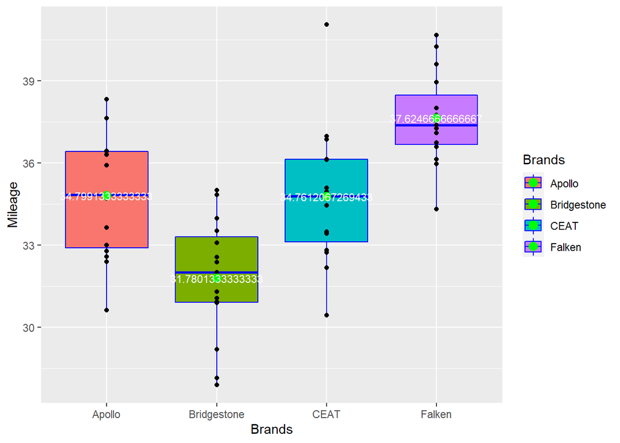

```r
ggplot(data = tire, title = "Mileage vs. Brand") +
geom_boxplot(color = "blue") +
geom_point() +
aes(x = Brands, y = Mileage, fill = Brands) +
stat_summary(fun = mean, colour = "green", geom = "point", shape=20, size=5) +
stat_summary(fun.y = mean, geom = "text", label = means$V1, size = 3, color= "white") +
xlab(label = "Brands") + ylab(label = "Mileage")
```

**Exercise 2:** Perform a one-way analysis of variance (use the `aov` function) and identify the sum of squares within and between from the anova table. State the null hypothesis we want to test in the context of the problem. Using the F-test and the respective p-value, what do you conclude?

Resp: SSB is 256.2908 (df = 3), and SSW = 266.6495 (df = 56). The null hypothesis states that there is not statistically significant difference between the means (lifetime) of any two tire brands. The ANOVA table shows that Pr(>F) = 2.78e-08. This means that the area under the F-distribution to the right of the computed F-statistic is in the millionths of a percentage point. Regardless of whether we choose p = 0.05, 0.01, or 0.001, the F-statistic always falls to the right of the critical value. Therefore, we reject the null hypothesis and conclude that there is indeed at least one pair of tire brands with different means in lifetimes not due to chance alone.

```r
head(x=tire)
```

```
##   Brands Mileage
## 1 Apollo  32.998
## 2 Apollo  36.435
## 3 Apollo  32.777
## 4 Apollo  37.637
## 5 Apollo  36.304
## 6 Apollo  35.915
```

```r
tire_aov <- aov(formula = Mileage ~ Brands, data = tire)
print("tire_aov:")
```

```
## [1] "tire_aov:"
```

```r
tire_aov
```

```
## Call:
##    aov(formula = Mileage ~ Brands, data = tire)
##
## Terms:
##                   Brands Residuals
## Sum of Squares  256.2908  266.6495
## Deg. of Freedom        3        56
##
## Residual standard error: 2.182108
## Estimated effects may be unbalanced
```

```r
print("tire_aov summarized:")
```

```
## [1] "tire_aov summarized:"
```

```r
summary(object = tire_aov)
```

```
##             Df Sum Sq Mean Sq F value   Pr(>F)
## Brands       3  256.3   85.43   17.94 2.78e-08 ***
## Residuals   56  266.6    4.76
## ---
## Signif. codes:  0 '***' 0.001 '**' 0.01 '*' 0.05 '.' 0.1 ' ' 1
```

**Exercise 3:** Briefly state the assumptions of a completely randomized design. Compute the residuals and check the respective assumptions for the tire data.

```r
# Checking for normality
shapiro.test(x = tire$Mileage)
```

```
##
##  Shapiro-Wilk normality test
##
## data:  tire$Mileage
## W = 0.98806, p-value = 0.8241
```

```r
mileage_mean <- mean(x = tire$Mileage)
print("mileage_mean:")
```

```
## [1] "mileage_mean:"
```

```r
print(mileage_mean)
```

```
## [1] 34.74129
```

```r
res <- tire$Mileage - mileage_mean
print("residuals:")
```

```
## [1] "residuals:"
```

```r
res
```

```
##  [1] -1.74328502  1.69371498 -1.96428502  2.89571498  1.56271498  1.17371498
##  [7] -0.04128502 -2.36228502 -1.11028502  1.67771498  1.68871498  0.09471498
## [13]  3.58671498 -4.11828502 -2.16628502 -1.21828502 -2.74628502  0.26471498
## [19] -6.86228502 -3.44428502 -3.67928502  0.09671498 -0.76528502 -2.18928502
## [25] -3.86028502 -6.59728502 -5.55728502 -1.66628502 -2.37628502 -3.81628502
## [31] -0.29563513 -1.93470386 -1.32629562  2.11989167  2.23148222  0.34016482
## [37]  0.21283702 -1.26612608 -4.31380195  1.39263501  0.04207440  1.37546246
## [43]  6.30871498 -2.57283245 -2.01504182  4.85471498  4.19571498  1.38271498
## [49]  2.95371498  1.84471498  1.22571498  1.99571498 -0.43128502  5.51071498
## [55]  2.64071498  5.92171498  2.35371498  3.26371498  3.01471498  2.52371498
```

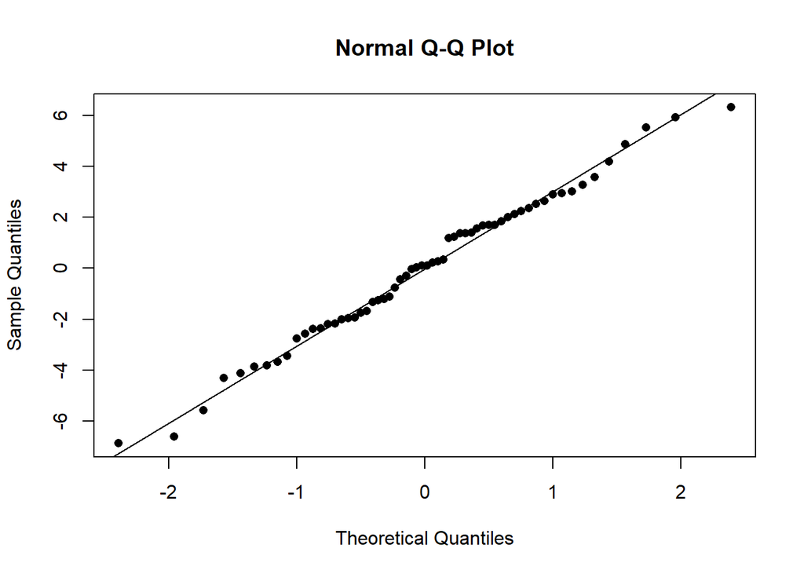

```r
qqnorm(y = res, pch = 16)
qqline(y = res)
```

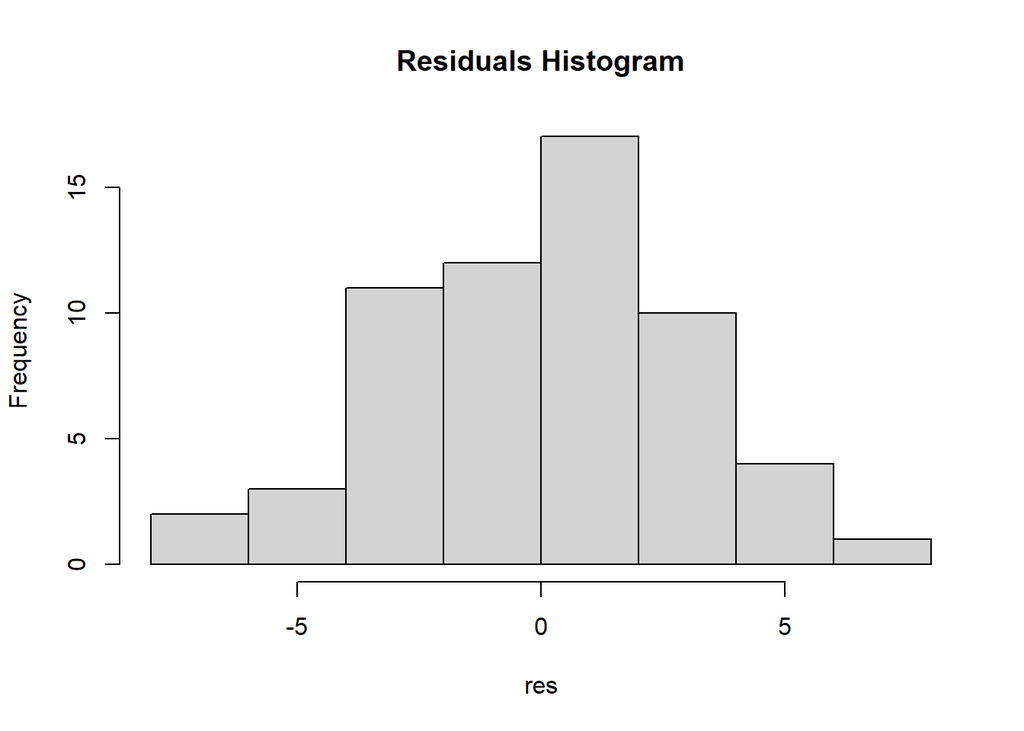

```r
hist(x = res, main = "Residuals Histogram")
```

**Exercise 4:** Perform multiple comparisons of the population means (hint: use `TukeyHSD`) and plot the 95% confidence intervals for all pairwise differences. Interpret the results. Which tire brand (or brands) would you recommend?

Resp: When considering only absolute differences between means of lifetime for two different brands, CEAT and Apollo have the least difference (very close to 0). On the other hand, the largest absolute difference between any pair of brands is Falken-Bridgestone, with Falken being having the higher mean. Therefore, we can deduce that Falken has the highest lifetime on average (verify with boxplot). From the data, Falken seems to be the best recommendation.

```r
tire_tukey <- TukeyHSD(x = tire_aov, conf.level = 0.95)
print("tukey-kramer test (95% confidence):")
```

```
## [1] "tukey-kramer test (95% confidence):"
```

```r
print(tire_tukey)
```

```
##   Tukey multiple comparisons of means
##     95% family-wise confidence level
##
## Fit: aov(formula = Mileage ~ Brands, data = tire)
##
## $Brands
##                           diff        lwr       upr     p adj
## Bridgestone-Apollo -3.01900000 -5.1288190 -0.909181 0.0020527
## CEAT-Apollo        -0.03792661 -2.1477456  2.071892 0.9999608
## Falken-Apollo       2.82553333  0.7157143  4.935352 0.0043198
## CEAT-Bridgestone    2.98107339  0.8712544  5.090892 0.0023806
## Falken-Bridgestone  5.84453333  3.7347143  7.954352 0.0000000
## Falken-CEAT         2.86345994  0.7536409  4.973279 0.0037424
```

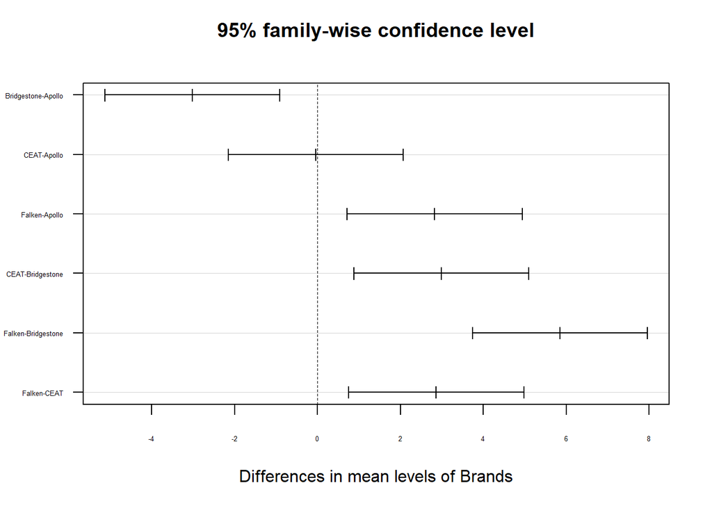

```r
plot(tire_tukey, cex.lab=1, cex.axis=0.4, las=1)
```